# Part II - (Ford GoBike System Data Exploration)

## by Okon Elizabeth Queen

## Investigation Overview

> The goal of this analysisis to explore the factors that affect the duration of a ride,the most popular start and end station, the longest duration of a ride, what gender rides the most.

## Dataset Overview

> This data set includes information about individual rides made in a bike-sharing system covering the greater San Francisco Bay area.There are 183,412 bike in the dataset with 16 features

## Visualization 1

> How does age affect the duration of the trip?

There is a weak negative correlation between the duration and the age. The older the user, the shorter the duration of the trip.

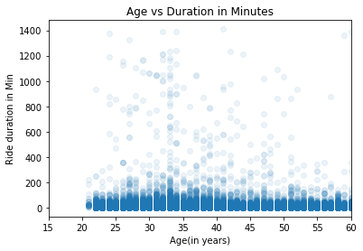

## Visualization 2

> How does user type affect the duration of the trip?

The visualisation shows that Customers ride for a longer period than Subscribers although most of the users are subscribers

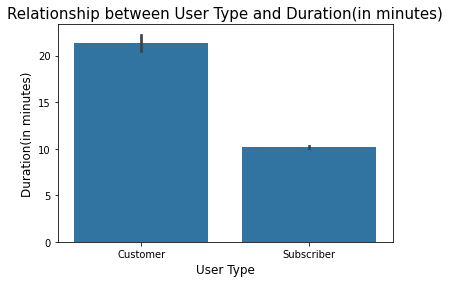

## Visualization 3

> How does age and gender affect bike share for trip?

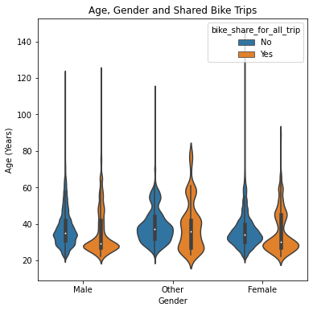